# Prediction Assignment

Neeraj Agarwal

July 9, 2019

## Executive Summary

### Background

Large amount of personal activity data can be collected using devices such as Jawbone Up, Nike FuelBand, and Fitbit. The goal of this project is to use data from accelerometers on the belt, forearm, arm, and dumbbell of 6 participants as they perform barbell lifts correctly and incorrectly 5 different ways.

Six young healthy participants were asked to perform one set of 10 repetitions of the Unilateral Dumbbell Biceps Curl in five different fashions: * Class A - exactly according to the specification * Class B - throwing the elbows to the front * Class C - lifting the dumbbell only halfway * Class D - lowering the dumbbell only halfway * Class E - throwing the hips to the front

```r
rm(list = ls()) ## Remove existing files
Garbage<-gc()

library(caret)
library(rpart)
library(rpart.plot)
library(RColorBrewer)
library(rattle)
library(randomForest)
library(e1071)

set.seed(1)

train.url <-
        "https://d396qusza40orc.cloudfront.net/predmachlearn/pml-training.csv"
test.url <-
        "https://d396qusza40orc.cloudfront.net/predmachlearn/pml-testing.csv"

path <- paste(getwd(), sep="")
train.file <- file.path(path, "pml-training.csv")
test.file <- file.path(path, "pml-testing.csv")

if (!file.exists(train.file)) {
        download.file(train.url, destfile=train.file)
}

if (!file.exists(test.file)) {
        download.file(test.url, destfile=test.file)
}

train.data <- read.csv(train.file, na.strings=c("NA"," ", "#DIV/0!"))
test.data <- read.csv(test.file, na.strings=c("NA"," ","#DIV/0!"))
```

## Data Analysis and remove unnecessary columns

```r
##head(train.data)
##head(test.data)
dim(train.data)
```

```
## [1] 19622   160
```

```r
dim(test.data)
```

```
## [1]  20 160
```

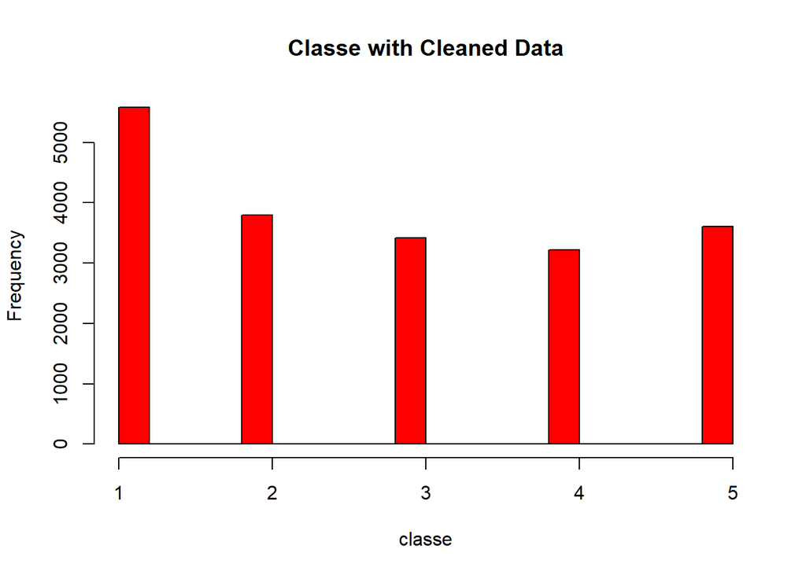

```r
# Drop colums with NAs
train.data <- train.data[, colSums(is.na(train.data)) == 0]
test.data <- test.data[, colSums(is.na(test.data)) == 0]

# Drop the first 7 columns as they're unnecessary for predicting.
train.data <- train.data[,8:length(colnames(train.data))]
test.data <- test.data[,8:length(colnames(test.data))]

# check the classe with cleaned data set by histogram
hist(as.numeric(train.data$classe), col = "red", xlab="classe",main = "Classe with Cleaned Data")
```

### Data Slicing

The training data is divided into two sets. This first is a training set with 30% of the data which is used to train the model. The second is a validation set used to assess model performance.

```r
in.train <- createDataPartition(train.data$classe, p=0.30, list=F)
train.data.final <- train.data[in.train, ]
validate.data.final <- train.data[-in.train, ]
```

## Apply Model and Analysis

```r
tr_cntl <- trainControl(method="cv",number=5)

# randomforest model
model_rf <- train(classe ~ ., data = train.data.final, method="rf",trControl=tr_cntl, prox=TRUE, allowParallel=TRUE)

model_rf
```

```
## Random Forest
##
## 5889 samples
##   52 predictor
##    5 classes: 'A', 'B', 'C', 'D', 'E'
##
## No pre-processing
## Resampling: Cross-Validated (5 fold)
## Summary of sample sizes: 4711, 4713, 4710, 4711, 4711
## Resampling results across tuning parameters:
##
##   mtry  Accuracy   Kappa
##    2    0.9743590  0.9675586
##   27    0.9750374  0.9684171
##   52    0.9634948  0.9538088
##
## Accuracy was used to select the optimal model using the largest value.
## The final value used for the model was mtry = 27.
```

# Apply Model Randonforest on the testing data set and check the accuracy

```r
# predict for the training set
predict_rf <- predict(model_rf, validate.data.final)

# accuracy for training set
accuracy <- confusionMatrix(validate.data.final$classe, predict_rf)$overall[1]

#Model Accuracy
accuracy
```

```
##  Accuracy
## 0.9825967
```

```r
# predict for the testing set
test_rf <- predict(model_rf, test.data[, -length(names(test.data))])

#results with test data
test_rf
```

```
##  [1] B A A A A E D B A A B C B A E E A B B B
## Levels: A B C D E
```

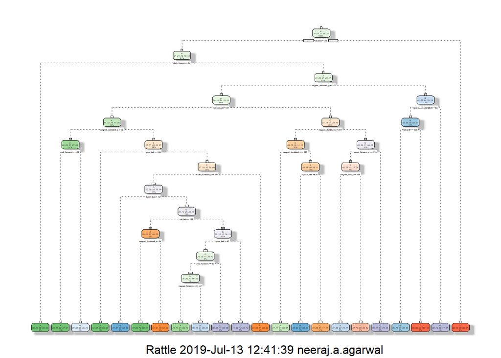

```r
##Decision Tree
treeModel <- rpart(classe ~ ., data=train.data.final, method="class")
fancyRpartPlot(treeModel)
```